# Horticulture Data (7.3.33 - 7.3.48)

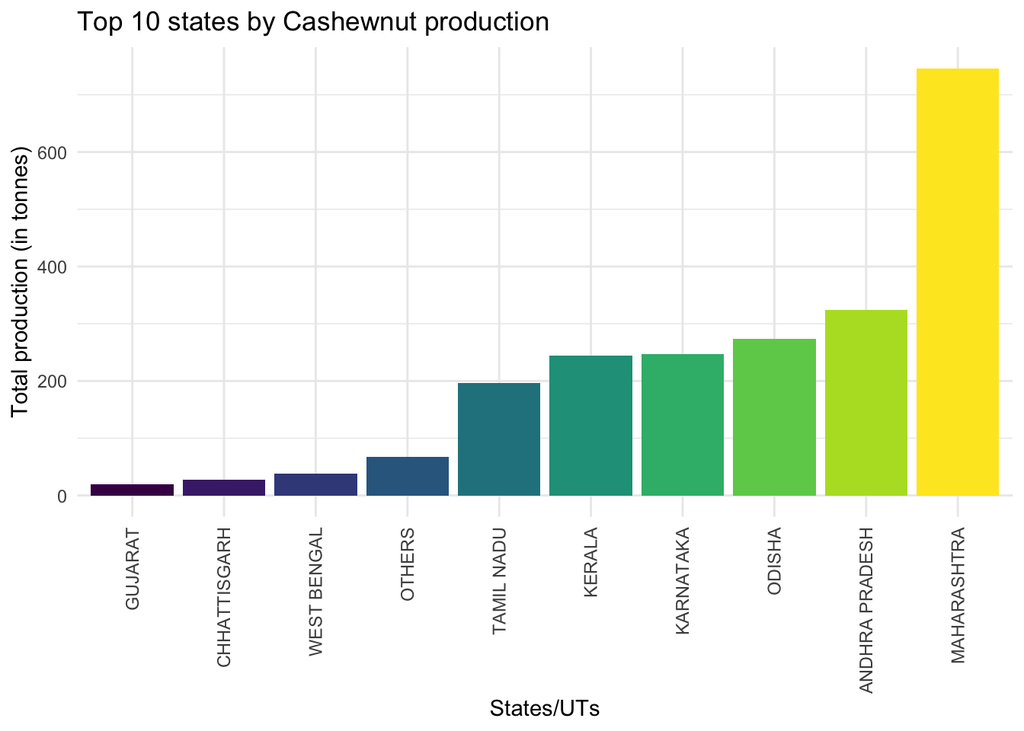

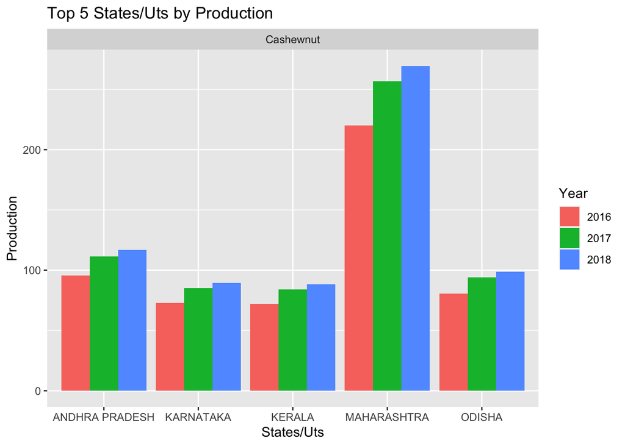

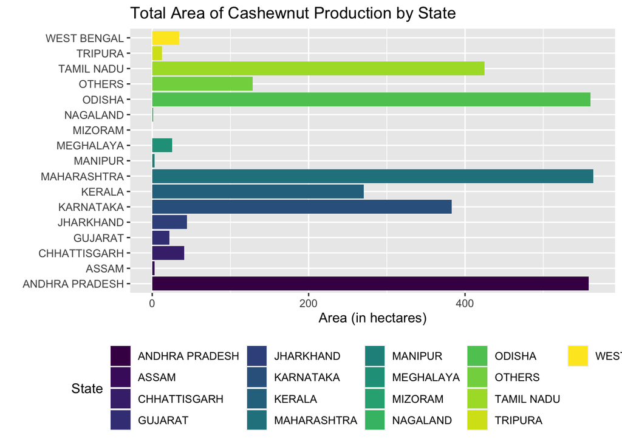

```
##  [1] "id"              "states"          "area_2016"       "production_2016"
##  [5] "area_2017"       "production_2017" "area_2018"       "production_2018"
##  [9] "table_name"      "team_name"
```

```
##  [1] "id"              "states"          "area_2016"       "production_2016"
##  [5] "area_2017"       "production_2017" "area_2018"       "production_2018"
##  [9] "table_name"      "team_name"
```

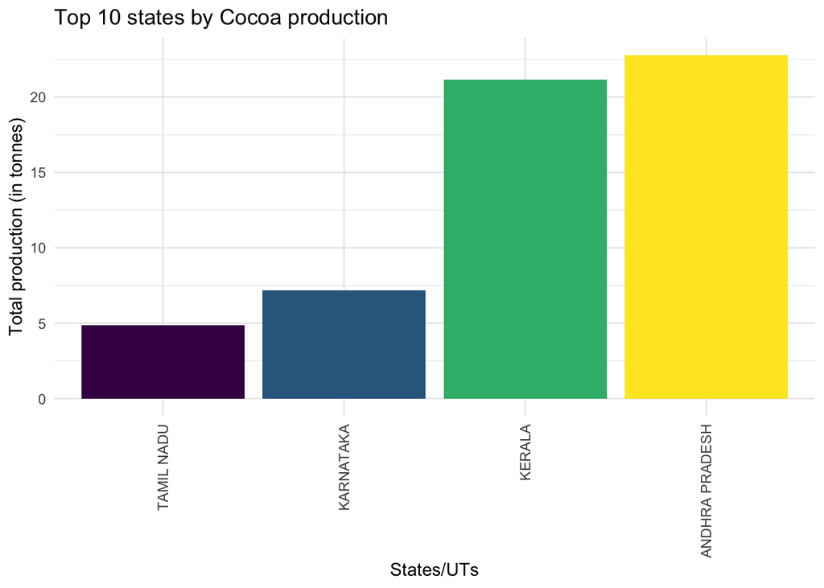

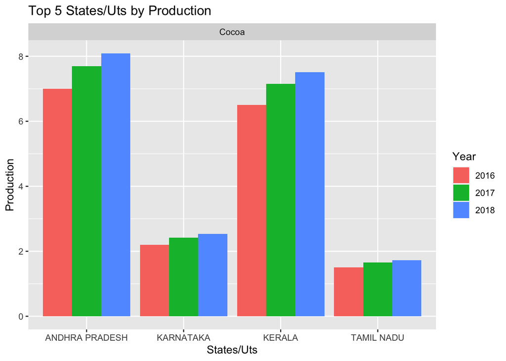

[figure not shown]

```
##  [1] "id"              "states"          "area_2016"       "production_2016"
##  [5] "area_2017"       "production_2017" "area_2018"       "production_2018"
##  [9] "table_name"      "team_name"
```

```
##  [1] "id"              "states"          "area_2016"       "production_2016"
##  [5] "area_2017"       "production_2017" "area_2018"       "production_2018"
##  [9] "table_name"      "team_name"
```

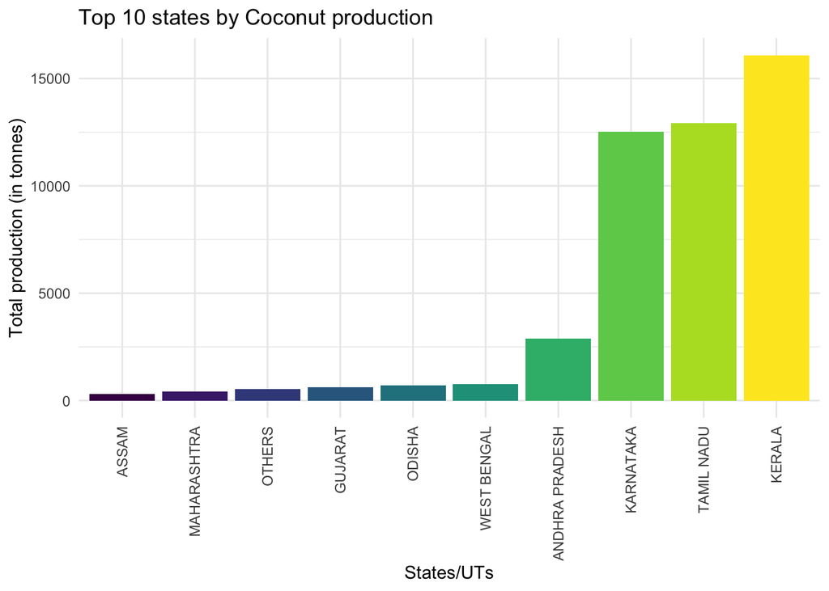

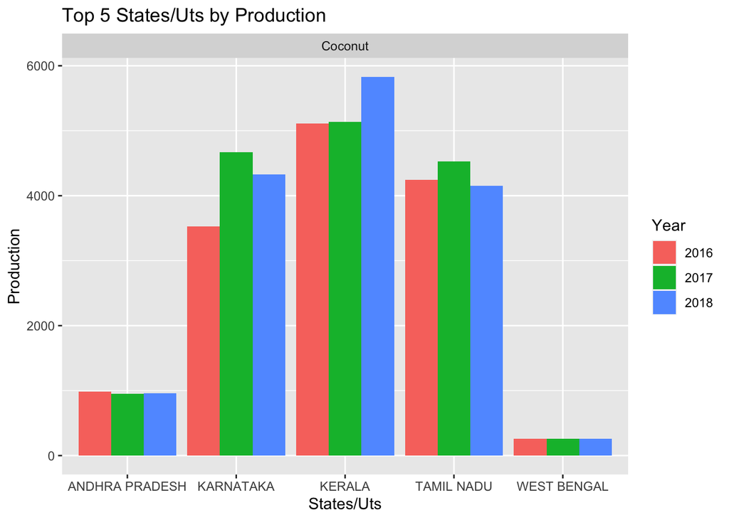

### Plots created by Ankit Kumar (7.3.33 - 7.3.37)

#### Plot Explanation

Overall, the plot indicates that crop production in India varies significantly by region, with each zone having its dominant crops. The production of certain crops is concentrated in specific regions, which can be attributed to differences in climate, soil type, and other environmental factors. Additionally, the plot highlights the importance of plantation crops and coconut in the Indian agriculture industry, which could have significant economic implications for the country.

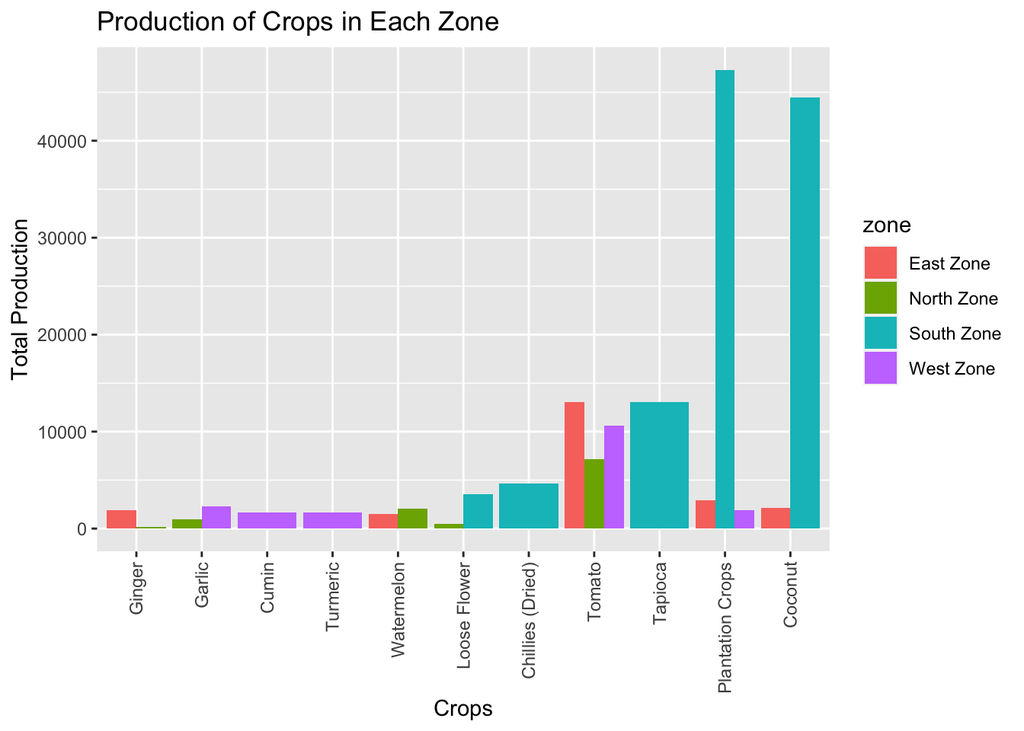

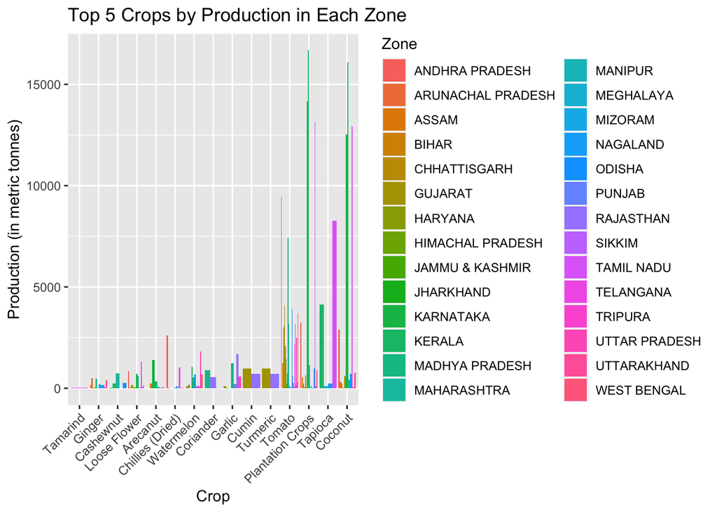

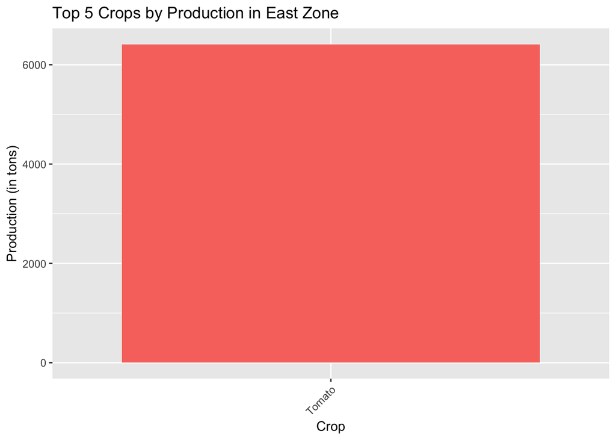

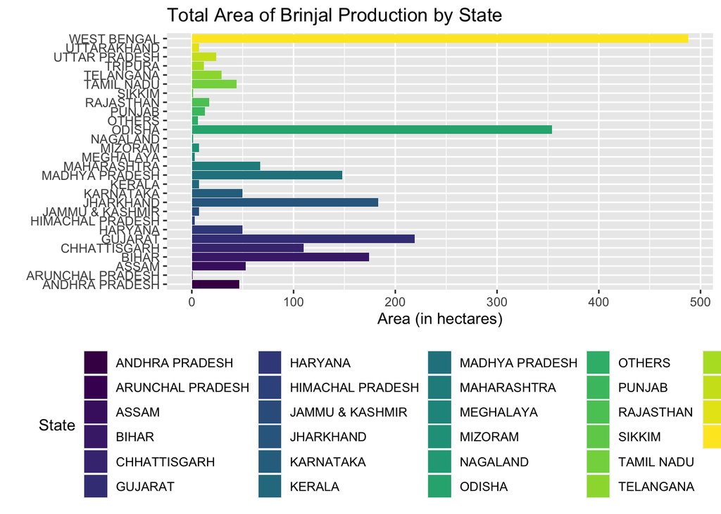

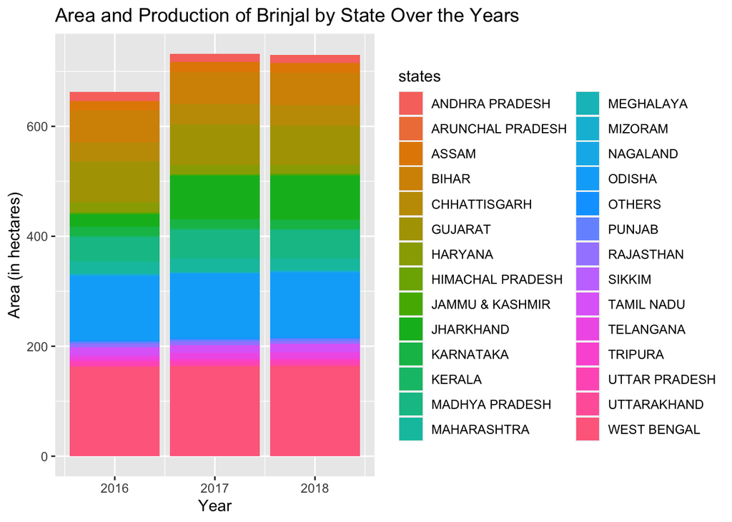

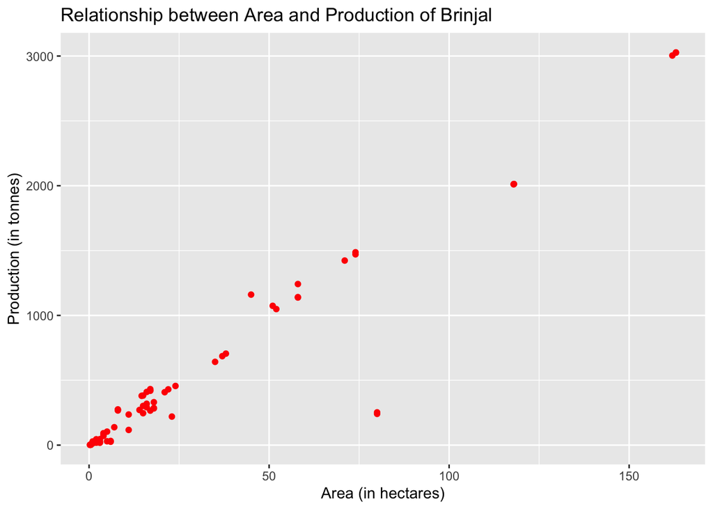

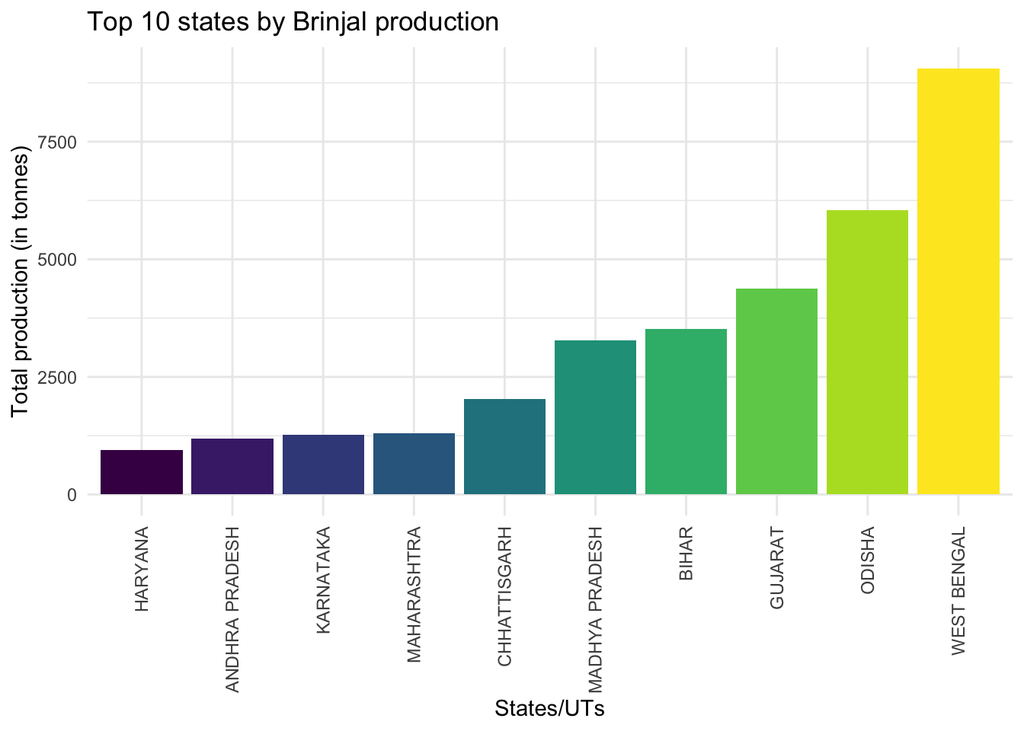

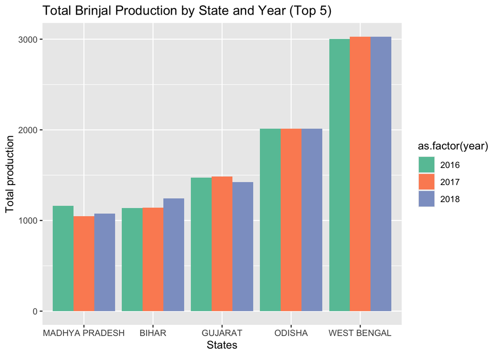

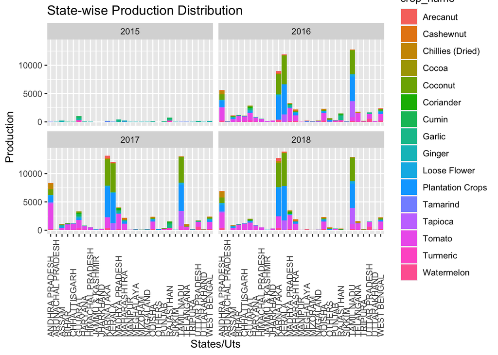

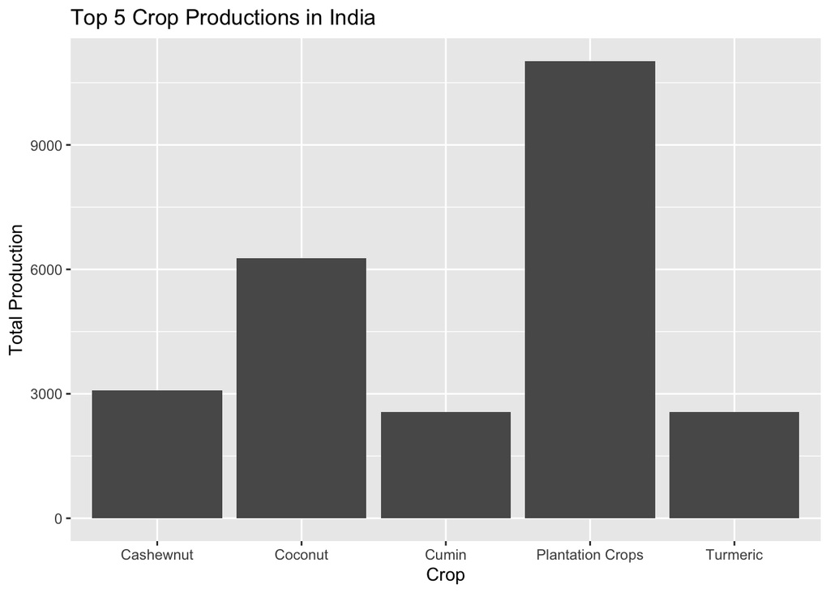

### Plots created by Yash Raj (7.3.44 - 7.3.48)

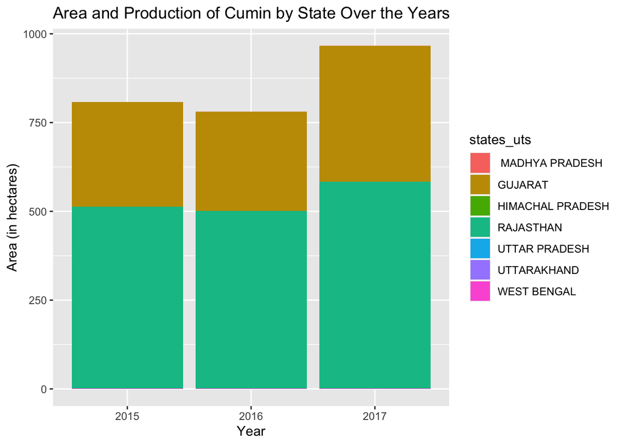

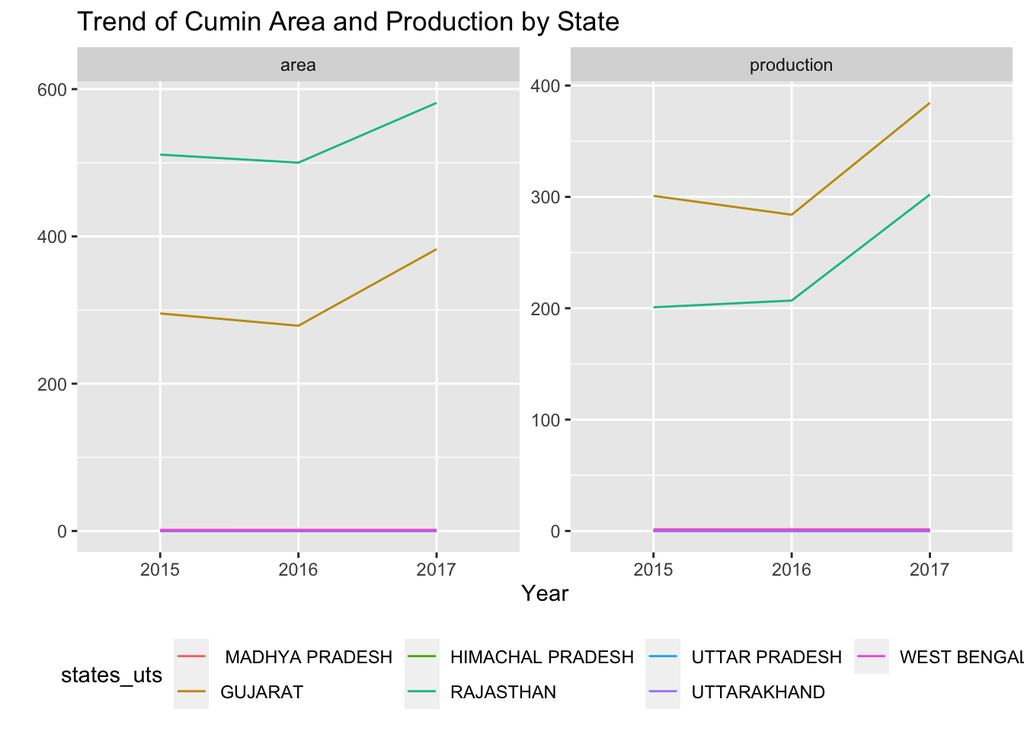

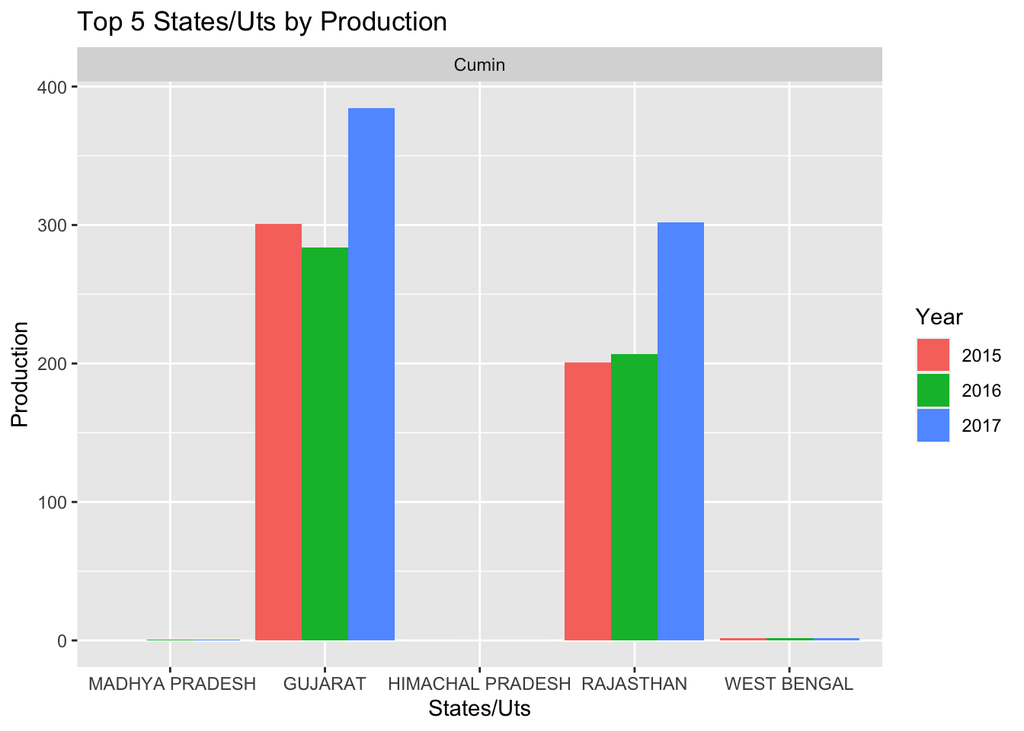

#### Plot Explanation

The code is generating two bar plots that show the total production of crops in the top 5 and bottom 5 states/UTs in India. The first plot shows the states/UTs with the highest production, while the second plot shows the states/UTs with the lowest production. Both plots have the states/UTs on the x-axis and the total production on the y-axis. The fill color of the bars represents the states/UTs.

Overall, these plots provide valuable insights into the distribution of crop production across different states/UTs in India and highlight the importance of understanding the local geography and climate in optimizing crop production.

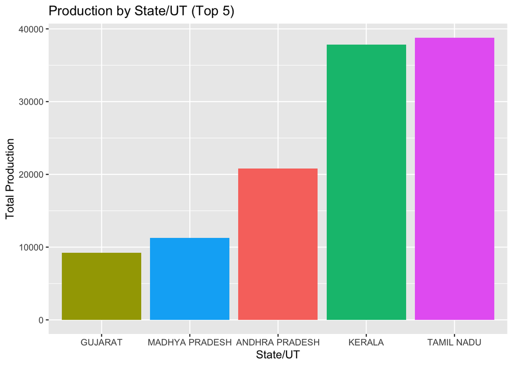

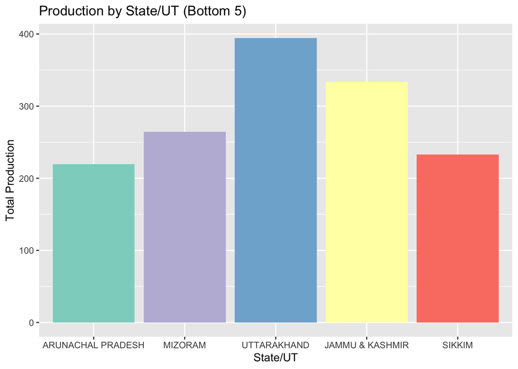